# Spotify Library of Music Analysis

Author: Rachel Tong

linkedin.com/in/rachelwtong

This project explores Spotify data from Kaggle which contains data pulled using the Spotify Web API to create an up-to-date and large scale dataset on its library of music. The dataset contains data on artists and tracks and will be used to analyze trends of popular songs over time and create predictive models using machine learning methods. This project is divided into three parts:

1. Spotify Library of Music Analysis - Exploratory Analysis of the Dataset
2. Song Recommender - Use of Distance Matrix to Create Recommender System
3. Popularity Predictor - Machine Learning Models to Predict Song Popularity

The following Kaggle Spotify dataset will be used for this analysis:

1. tracks 2021.csv (Spotify Web API data pulled in 2021 containing song characteristics and release year)

Specific details about track characteristics can be found [here](https://developer.spotify.com/documentation/web-api/reference/#object-audiofeaturesobject).

### Notebook Set Up & Data Cleaning

```python
import pandas as pd
import numpy as np
import matplotlib.pyplot as plt
import seaborn as sns
%matplotlib inline
import statsmodels.formula.api as smf
from scipy.spatial import distance
from sklearn.linear_model import LinearRegression as lr
from sklearn.model_selection import train_test_split
from sklearn.model_selection import cross_val_score
from sklearn.tree import DecisionTreeRegressor as dtr
from sklearn.ensemble import RandomForestRegressor as rf
from sklearn.metrics import mean_squared_error as mse
```

```python
df = pd.read_csv('tracks 2021.csv')
df = df.replace('empty',np.nan)
```

```python
df['year'] = df['release_date'].str.strip().str[0:4] # add a column for song year
df['year'] = df['year'].astype(int)
```

```python
df = df.dropna(axis=0) # removing NAs
df = df.drop(['id','id_artists'],axis=1) # removing irrelevant columns
df = df.sort_values('popularity',ascending=False).drop_duplicates(subset=['name','duration_ms','artists'])
df = df.drop(df.loc[df['popularity']==0].index)

df.head()
```

|  | name | popularity | duration_ms | explicit | artists | release_date | danceability | energy | key | loudness | mode | speechiness | acousticness | instrumentalness | liveness | valence | tempo | time_signature | year |
| --- | --- | --- | --- | --- | --- | --- | --- | --- | --- | --- | --- | --- | --- | --- | --- | --- | --- | --- | --- |
| 93802 | Peaches (feat. Daniel Caesar & Giveon) | 100 | 198082 | 1 | ['Justin Bieber', 'Daniel Caesar', 'Giveon'] | 2021-03-19 | 0.677 | 0.696 | 0 | -6.181 | 1 | 0.1190 | 0.3210 | 0.000000 | 0.420 | 0.464 | 90.030 | 4 | 2021 |
| 93803 | drivers license | 99 | 242014 | 1 | ['Olivia Rodrigo'] | 2021-01-08 | 0.585 | 0.436 | 10 | -8.761 | 1 | 0.0601 | 0.7210 | 0.000013 | 0.105 | 0.132 | 143.874 | 4 | 2021 |
| 93804 | Astronaut In The Ocean | 98 | 132780 | 0 | ['Masked Wolf'] | 2021-01-06 | 0.778 | 0.695 | 4 | -6.865 | 0 | 0.0913 | 0.1750 | 0.000000 | 0.150 | 0.472 | 149.996 | 4 | 2021 |
| 92811 | telepatía | 97 | 160191 | 0 | ['Kali Uchis'] | 2020-12-04 | 0.653 | 0.524 | 11 | -9.016 | 0 | 0.0502 | 0.1120 | 0.000000 | 0.203 | 0.553 | 83.970 | 4 | 2020 |
| 92810 | Save Your Tears | 97 | 215627 | 1 | ['The Weeknd'] | 2020-03-20 | 0.680 | 0.826 | 0 | -5.487 | 1 | 0.0309 | 0.0212 | 0.000012 | 0.543 | 0.644 | 118.051 | 4 | 2020 |

```python
df.columns
```

```
Index(['name', 'popularity', 'duration_ms', 'explicit', 'artists',
       'release_date', 'danceability', 'energy', 'key', 'loudness', 'mode',
       'speechiness', 'acousticness', 'instrumentalness', 'liveness',
       'valence', 'tempo', 'time_signature', 'year'],
      dtype='object')
```

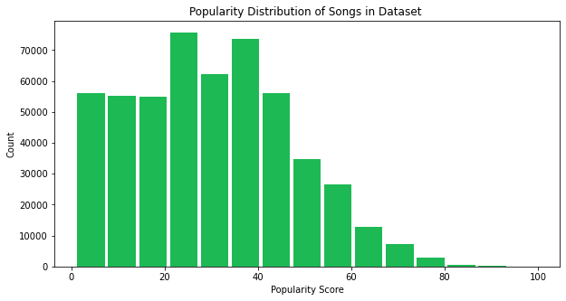

```python
fig,ax = plt.subplots(figsize=(10,5))
df['popularity'].plot.hist(ax=ax,bins=15,color='#1DB954',rwidth=0.9)
ax.set_title("Popularity Distribution of Songs in Dataset ")
ax.set_xlabel('Popularity Score')
ax.set_ylabel('Count')
plt.show()
```

There are many very unpopular songs in this dataset (i.e. songs with popularity score 0, which was removed from the dataset)

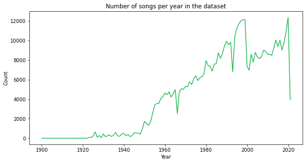

```python
fig,ax = plt.subplots(figsize=(10,5))
df.groupby('year')['name'].count().plot(ax=ax,color='#1DB954')
ax.set_title("Number of songs per year in the dataset")
ax.set_xlabel('Year')
ax.set_ylabel('Count')
plt.show()
```

```python
df1 = df.loc[df['year']>1950]
```

The number of songs per year in the dataset is uneven, which would make certain characteristics very volatile over time. The quantity of songs per year has drastically increased compared to the early 1900s. Based on the graph, only songs released from 1950 and onwards will be used to ensure a meaningful sample of songs for each year.

## 1) Analysis of Trends Over Time

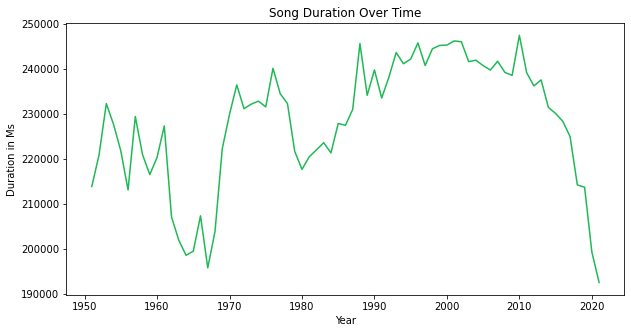

```python
filtered_years = [i for i in range(1950,2030,10)]

avg_yearly_duration = df1.groupby('year',as_index=False)['duration_ms'].mean().sort_values(by='year')

fig,ax = plt.subplots(figsize=(10,5))
ax.plot(avg_yearly_duration['year'],avg_yearly_duration['duration_ms'],color="#1DB954")

ax.set_xticks(filtered_years)
ax.set_title("Song Duration Over Time")
ax.set_ylabel("Duration in Ms")
ax.set_xlabel("Year")
plt.show()
```

Songs have generally been getting longer over time with some periods of shorter songs that may correspond with what the characteristics of the popular song genre was at that time. The year with the longest songs on average was 2010, and average song duration has been decreasing since then. This trend correlates with the general decrease in media content duration that has been reported with the advent of short-form media.

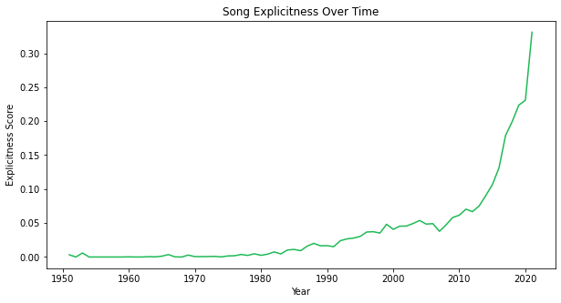

```python
avg_yearly_explicit = df1.groupby('year',as_index=False)['explicit'].mean().sort_values(by='year')

fig,ax = plt.subplots(figsize=(10,5))
ax.plot(avg_yearly_explicit['year'],avg_yearly_explicit['explicit'],color="#1DB954")

ax.set_title("Song Explicitness Over Time")
ax.set_ylabel("Explicitness Score")
ax.set_xlabel("Year")
plt.show()
```

Also, songs have become increasingly more explicit over time. The result of this analysis is in alignment with [research of number one singles from 1958 to 2018](https://www.newsweek.com/songs-explicit-lyrics-popular-increase-billboard-spotify-583551) showing that over two-thirds of top Billboard 100 songs are explicit.

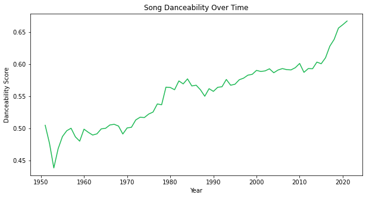

```python
avg_yearly_dance = df1.groupby('year',as_index=False)['danceability'].mean().sort_values(by='year')

fig,ax = plt.subplots(figsize=(10,5))
ax.plot(avg_yearly_dance['year'],avg_yearly_dance['danceability'],color="#1DB954")

ax.set_title("Song Danceability Over Time")
ax.set_ylabel("Danceability Score")
ax.set_xlabel("Year")
plt.show()
```

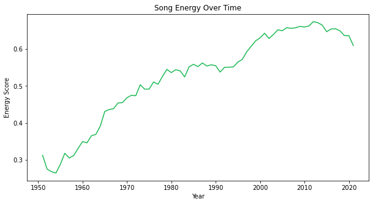

```python
avg_yearly_energy = df1.groupby('year',as_index=False)['energy'].mean().sort_values(by='year')

fig,ax = plt.subplots(figsize=(10,5))
ax.plot(avg_yearly_energy['year'],avg_yearly_energy['energy'],color="#1DB954")

ax.set_title("Song Energy Over Time")
ax.set_ylabel("Energy Score")
ax.set_xlabel("Year")
plt.show()
```

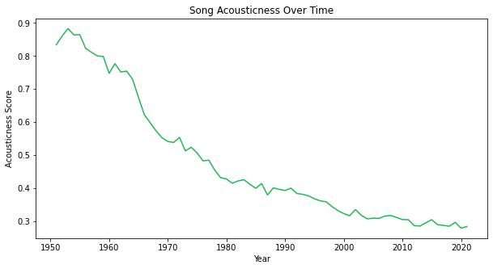

```python
avg_yearly_acou = df1.groupby('year',as_index=False)['acousticness'].mean().sort_values(by='year')

fig,ax = plt.subplots(figsize=(10,5))
ax.plot(avg_yearly_acou['year'],avg_yearly_acou['acousticness'],color="#1DB954")

ax.set_title("Song Acousticness Over Time")
ax.set_ylabel("Acousticness Score")
ax.set_xlabel("Year")
plt.show()
```

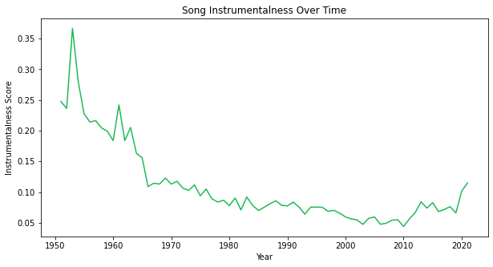

```python
avg_yearly_ins = df1.groupby('year',as_index=False)['instrumentalness'].mean().sort_values(by='year')

fig,ax = plt.subplots(figsize=(10,5))
ax.plot(avg_yearly_ins['year'],avg_yearly_ins['instrumentalness'],color="#1DB954")
#ax.set_xticks(filtered_years)
ax.set_title("Song Instrumentalness Over Time")
ax.set_ylabel("Instrumentalness Score")
ax.set_xlabel("Year")
plt.show()
```

#### Instrumentalness predicts whether a track contains no vocals. The closer the instrumentalness value is to 1.0, the greater likelihood the track contains no vocal content. This makes sense because in recent years, genres that place a trend on instrumentalness--such as jazz and classical--have become increasingly unpopular.

Another interesting explanation for this phenomenon is [technological innovation in music](https://www.rollingstone.com/music/music-lists/24-inventions-that-changed-music-16471/jtm45-amplifier-1962-68059/) towards the end of the 1900s. Prior to that time, instruments that were naturally loud (violin, piano, trumpet) were typically used in performances. With new technology such as the pickup, microphone, and portable amp, instruments that were not loud before (acoustic/electric/bass guitar, voice) were [able to grow in popularity in large-audience settings](https://www.ongenre.com/article/opinion/instrumental-music-in-decline-where-have-instrumentals-gone/). Furthermore, it is much harder to combine traditional stringed instruments with the voice, so the rise in electronic sounds also meant a rise in vocal expression in songs.

Interestingly, the technological innovation music caused a consequent democratization of expression, meaning that artists without any classical technical ability can rise in popularity. Widening the chasm between instrumentalness and popularity is the fact that classical music education is [becoming increasingly privatized](https://www.gramophone.co.uk/blogs/article/why-are-our-schools-pushing-classical-music-to-the-margins).

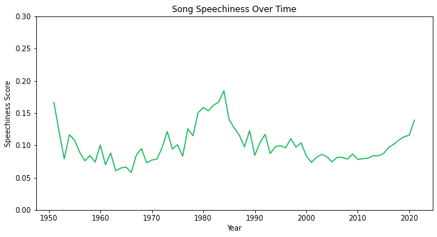

```python
avg_yearly_sp = df1.groupby('year',as_index=True)['speechiness'].mean().sort_index()

fig,ax = plt.subplots(figsize=(10,5))
ax.plot(avg_yearly_sp,color='#10B954')

ax.set_title("Song Speechiness Over Time")
ax.set_ylabel("Speechiness Score")
ax.set_ylim(0,0.3)
ax.set_xlabel("Year")
plt.show()
```

One possible explanation for this spike is the [Golden Age of Hip Hop](https://historyofthehiphop.wordpress.com/music-genres/golden-age-hip-hop/), which took place from the mid 1980s to the mid 1990s, and can be described by greats advances in electronic music technology and rapping technique. During this time, music "witnessed the best recordings form some of the biggest rappers in the genre’s history," and "rhymers like PE’s Chuck D, Big Daddy Kane, KRS-One, Rakim, and LL Cool J basically invented the complex wordplay and lyrical kung-fu of later hip-hop.” Song speechiness before and after this period was more stable, and it's possible that we will continue to see a rise in speechiness along with the decline in instrumentalness as described above.

## 2) Analysis of Trends in Popular Music

Songs with popularity scores over 80 will be categorized as very popular. Due to the small sample size that fits this criteria, songs with popularity scores over 50 will be used as a second group to corroborate trends. </b>

Songs with popularity scores under 10 will be categorized as very unpopular. A second group of songs with popularity scores under 50 will be used to corroborate trends.

### a) Danceability in Popular Songs vs. Danceability in Unpopular Songs

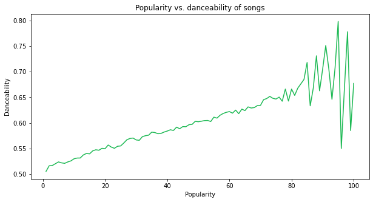

```python
fig,ax = plt.subplots(figsize=(10,5))
pop_danceability = df1.groupby('popularity')['danceability'].mean()
pop_danceability.plot(ax=ax,color='#1DB954')
ax.set_title("Popularity vs. danceability of songs")
ax.set_xlabel("Popularity")
ax.set_ylabel("Danceability")
plt.show()
```

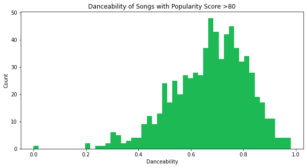

```python
fig,ax = plt.subplots(figsize=(10,5))
df1.loc[df1['popularity']>80,'danceability'].plot.hist(ax=ax,bins=50,color="#1DB954")
ax.set_title("Danceability of Songs with Popularity Score >80")
ax.set_xlabel("Danceability")
ax.set_ylabel("Count")
plt.show()
```

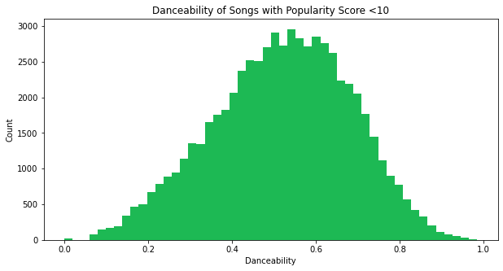

```python
fig,ax = plt.subplots(figsize=(10,5))
df1.loc[df1['popularity']<10,'danceability'].plot.hist(ax=ax,bins=50,color="#1DB954")
ax.set_title("Danceability of Songs with Popularity Score <10")
ax.set_xlabel("Danceability")
ax.set_ylabel("Count")
plt.show()
```

#### Songs with a popularity score over 80 are more likely to have higher danceability scores as well while songs with a popularity score under 10 are more likely to have average danceability scores.

### b) Explicitness in Popular Songs vs. Explicitness in Unpopular Songs

```
There are 66269 songs with a popularity score > 50
```

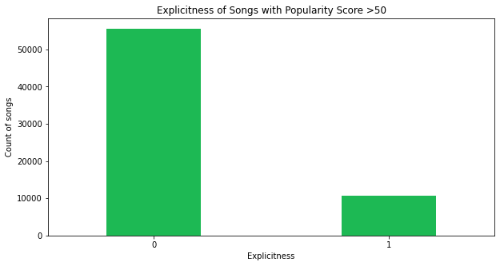

```python
print('There are %d songs with a popularity score > 50' % len(df1.loc[df1['popularity']>50].index))

pop_over_50_exp = df1.loc[df1['popularity']>50,'explicit'].reset_index()

fig,ax = plt.subplots(figsize=(10,5))
pop_over_50_exp.groupby('explicit').count().plot.bar(ax=ax,width=0.4,color='#1DB954')
ax.set_title("Explicitness of Songs with Popularity Score >50")
ax.set_xlabel("Explicitness")
ax.set_ylabel("Count of songs")
plt.xticks(rotation = 0)
ax.get_legend().remove()
plt.show()
```

```
There are 435727 songs with a popularity score < 50
```

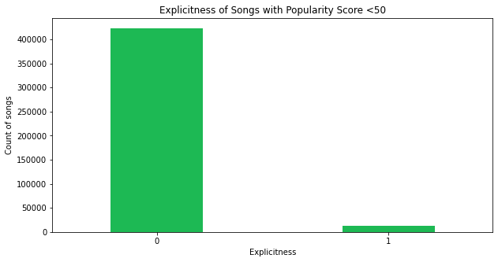

```python
print('There are %d songs with a popularity score < 50' % len(df1.loc[df1['popularity']<50].index))

fig,ax = plt.subplots(figsize=(10,5))
df1.loc[df1['popularity']<50,'explicit'].reset_index().groupby('explicit').count().plot.bar(ax=ax,width=0.4,color='#1DB954')
ax.set_title("Explicitness of Songs with Popularity Score <50")
ax.set_xlabel("Explicitness")
ax.set_ylabel("Count of songs")
plt.xticks(rotation = 0)
ax.get_legend().remove()
plt.show()
```

Songs with popularity scores over 50 are more likely to be explicit compared to songs with popularity scores under 50.

### c) Liveness in Popular Songs vs. Unpopular Songs

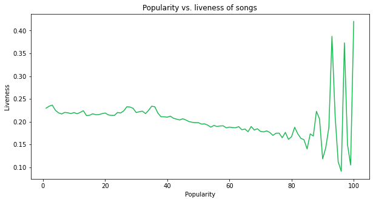

```python
fig,ax = plt.subplots(figsize=(10,5))
pop_danceability = df1.groupby('popularity')['liveness'].mean()
pop_danceability.plot(ax=ax,color='#1DB954')
ax.set_title("Popularity vs. liveness of songs")
ax.set_xlabel("Popularity")
ax.set_ylabel("Liveness")
plt.show()
```

#### The liveness of songs decreases slightly as popularity increases. One explanation for this trend could be the fact that higher liveness values represent an increased probability that the track was performed live. Recording a song in a studio indicates more artist control of the sound, creating a higher quality listening experience for the listener, which would lead studio recorded songs to become more popular than lives ones.

Most songs are in between the liveness range of 0.10 and 0.25. The data is very noisy as popularity increases, since the number of songs in the dataset decreases as popularity score increases.

### d) Energy in Popular Songs vs. Unpopular Songs

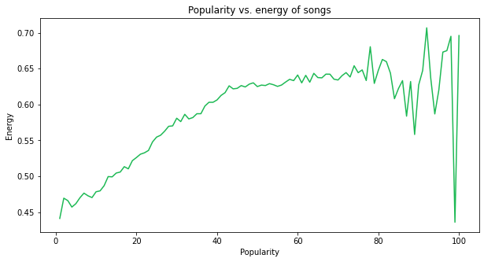

```python
fig,ax = plt.subplots(figsize=(10,5))
pop_danceability = df1.groupby('popularity')['energy'].mean()
pop_danceability.plot(ax=ax,color='#1DB954')
ax.set_title("Popularity vs. energy of songs")
ax.set_xlabel("Popularity")
ax.set_ylabel("Energy")
plt.show()
```

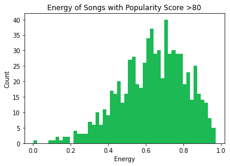

```python
fig,ax = plt.subplots()
df1.loc[df1['popularity']>80,'energy'].plot.hist(ax=ax,bins=50,color='#1DB954')
ax.set_title("Energy of Songs with Popularity Score >80")
ax.set_xlabel("Energy")
ax.set_ylabel("Count")
plt.show()
```

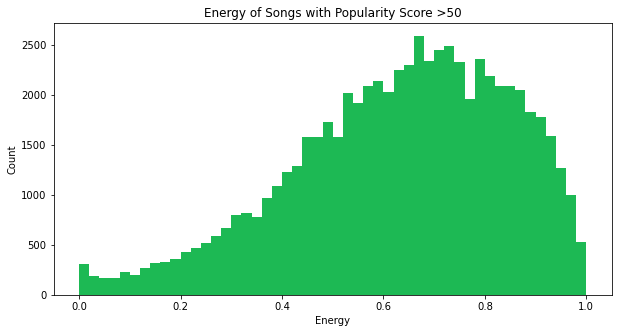

```python
fig,ax = plt.subplots(figsize=(10,5))
df1.loc[df1['popularity']>50,'energy'].plot.hist(ax=ax,bins=50,color='#1DB954')
ax.set_title("Energy of Songs with Popularity Score >50")
ax.set_xlabel("Energy")
ax.set_ylabel("Count")
plt.show()
```

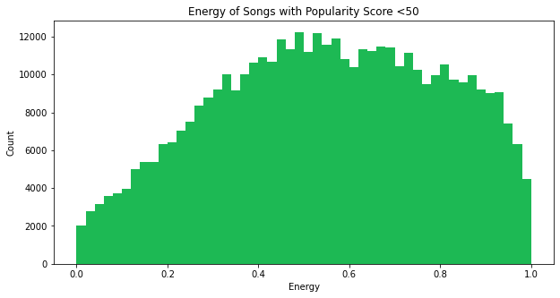

```python
fig,ax = plt.subplots(figsize=(10,5))
df1.loc[df1['popularity']<50,'energy'].plot.hist(ax=ax,bins=50,color='#1DB954')
ax.set_title("Energy of Songs with Popularity Score <50")
ax.set_xlabel("Energy")
ax.set_ylabel("Count")
plt.show()
```

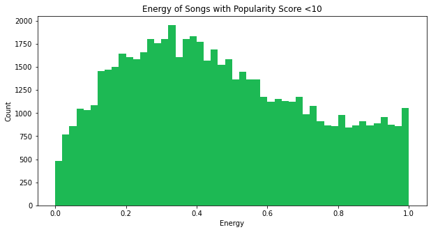

```python
fig,ax = plt.subplots(figsize=(10,5))
df1.loc[df1['popularity']<10,'energy'].plot.hist(ax=ax,bins=50,color='#1DB954')
ax.set_title("Energy of Songs with Popularity Score <10")
ax.set_xlabel("Energy")
ax.set_ylabel("Count")
plt.show()
```

#### Energy represents a perceptual measure of intensity and activity. From these four graphs, we can see that the most popular songs will likely have higher energy scores will the least popular songs typically have lower energy scores.

## 3) Recommending Similar Songs based on Distance Matrix

```python
def find_similar_songs(person,song,artist):
    try:
        # making everything lowercase
        song = song.lower()
        artist = artist.lower()
        df1.loc[:,'name'] = df1['name'].str.lower()
        df1.loc[:,'artists'] = df1['artists'].str.lower()
        # if a row in the name column contains the song input string and
        #    a row in the artist column contains the artist input string,
        #    then select the first name from the dataframe and assign it to the variable correct_song_name
        correct_song_info = df1[(df1['name'].str.contains(song)) & (df1['artists'].str.contains(artist))]
        correct_song_name = correct_song_info['name'].iloc[0]
        print('Hi %s, the song you are looking for is %s by %s' % (person, correct_song_name, correct_song_info['artists'].iloc[0][1:-1]))

        # create a song representation of the 10,000 most popular songs based on
        #    5 song characteristics, set index as song name
        songs_rep = df1.sort_values('popularity', ascending=False).loc[df1['popularity']>30].iloc[0:40000].loc[:,['name','danceability','speechiness', 'energy','valence', 'acousticness']].set_index('name')

        # create a distance matrix of the songs
        top_songs_dist = pd.DataFrame(distance.cdist(songs_rep,songs_rep),index=songs_rep.index,columns=songs_rep.index)

        # create dataframe similar_song from the distance matrix using on the song input
        similar_songs = top_songs_dist[correct_song_name].sort_values().to_frame().reset_index()

        similar_songs_pop = similar_songs.merge(df1[['name','popularity','artists']],how='left')

        similar_songs_pop = similar_songs_pop.drop_duplicates(subset=['name'])
        similar_songs_pop.set_index('name',inplace=True)
        similar_songs_pop.index.rename('Songs similar to %s by %s'% (song.title(), correct_song_info['artists'].iloc[0][1:-1]),inplace=True)
        similar_songs_pop.index=similar_songs_pop.index.str.title()

        # renaming columns and fixing capitalization
        similar_songs_pop.columns = ['Distance score','Popularity','Artists']
        similar_songs_pop.loc[:,'Artists'] = similar_songs_pop['Artists'].str.title()


        # return the top 10 most similar songs out of the 10,000 most popular songs
        print("Here are 10 songs you might like!")
        return similar_songs_pop.iloc[1:10]
    except:
        print('Sorry, song not available')

person = str(input("Enter your name: "))
song_input = str(input("Song: "))
artist_input = str(input("Artist: "))
find_similar_songs(person,song_input,artist_input)
```

```
Enter your name: Rachel
Song: peaches
Artist: justin bieber
```

```
Hi Rachel, the song you are looking for is peaches (feat. daniel caesar & giveon) by 'justin bieber', 'daniel caesar', 'giveon'
Here are 10 songs you might like!
```

| Songs similar to Peaches by 'justin bieber', 'daniel caesar', 'giveon' | Distance score | Popularity | Artists |
| --- | --- | --- | --- |
| Let You Down | 0.025179 | 83 | ['Nf'] |
| Zor | 0.036742 | 62 | ['Lil Zey'] |
| Mörder | 0.041881 | 62 | ['Bonez Mc', 'Raf Camora', 'Gzuz'] |
| Moulaga | 0.043532 | 68 | ["Heuss L'Enfoiré", 'Jul'] |
| Hear Me Calling | 0.046130 | 75 | ['Juice Wrld'] |
| Loser | 0.049689 | 71 | ['Beck'] |
| Speed Racer | 0.061581 | 69 | ['Masked Wolf'] |
| Facetime | 0.063372 | 61 | ['Dardan'] |
| Amantes Y Amigos | 0.063687 | 70 | ['Arcangel', 'Sech'] |

## 4) Predicting Song Popularity based on Characteristics

### Three methods will be used to predict song popularity based on song characteristics. </b>

a) Linear Regression

b) Random Forest

c) Decision Tree

Model Evaluation

Prior to using the three machine learning models to predict song popularity based on certain characteristics, the covariance between characteristics and popularity was calculated to determine which characteristics will likely have the most predictive power.

```python
# modifying the df to include song characteristics and name only
df_char = df1.drop(['artists','release_date','mode','time_signature'],axis=1)
```

```python
# finding ALL important characteristics that impact popularity

corr = {}

variables = df_char.columns.tolist()[1:]

for var in variables:
    corr[var] = np.corrcoef(df_char[[var, "popularity"]].T)[0][1]

{k: v for k, v in sorted(corr.items(), key=lambda item: item[1])}
```

```
{'acousticness': -0.2787423864375935,
 'instrumentalness': -0.14546201203183315,
 'liveness': -0.05441787080081188,
 'valence': -0.014758064147390533,
 'speechiness': -0.009667137054150399,
 'key': 0.01812437748579898,
 'duration_ms': 0.024307378090025533,
 'tempo': 0.04656776776451944,
 'danceability': 0.1846560349632212,
 'explicit': 0.2162198788677745,
 'energy': 0.22616150224362244,
 'loudness': 0.2891093991695464,
 'year': 0.5343126265618912,
 'popularity': 1.0}
```

```python
df_char_2020 = df_char.loc[df_char['year']==2020]
```

```python
# finding the most important 2020 characteristics impact popularity

covar = {}

variables = df_char_2020.columns.tolist()[1:]

for var in variables:
    covar[var] = np.corrcoef(df_char_2020[[var, "popularity"]].T)[0][1]

{k: v for k, v in sorted(covar.items(), key=lambda item: item[1])}
```

```
{'instrumentalness': -0.42553132167306534,
 'liveness': -0.22553120375006439,
 'energy': -0.12476199928393637,
 'duration_ms': -0.07435885481424606,
 'tempo': -0.0322836898539073,
 'key': 0.005210389651871633,
 'speechiness': 0.09982086306745722,
 'acousticness': 0.12249525419756438,
 'valence': 0.14781693726606734,
 'loudness': 0.18670445072395642,
 'explicit': 0.23171173823460023,
 'danceability': 0.26551704725621667,
 'popularity': 1.0,
 'year': nan}
```

#### The four characteristics with the strongest correlation to popularity are loudness, energy, explicitness, and acousticness for songs all songs in df1 (from 1950 to 2021).

For 2020 only, the four characteristics most highly correlated to popularity are danceability, explicitness, instrumentalness, and liveness.

### a) Linear Regression

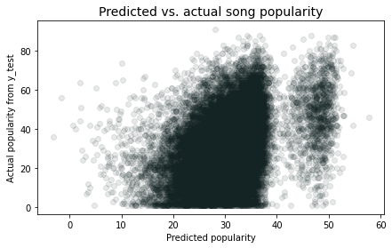

```python
fig,ax = plt.subplots(figsize=(7,4))

X_train, X_test, y_train, y_test = train_test_split
(df_char[["explicit",'loudness','energy','acousticness']],df_char['popularity'],train_size=.95)

model = lr().fit(X=X_train, y=y_train)

y_hat = model.predict(X_test)

plt.scatter(y_hat, y_test,alpha=0.1,color='#142424') # plotting the predicted value on the x axis, actual value on the y axis
ax.set_xlabel('Predicted popularity')
ax.set_ylabel('Actual popularity from y_test')
ax.set_title("Predicted vs. actual song popularity",size=14)
plt.show()
```

Because this model was trained on all the data (not just one year), we can see that there is little correlation between the most correlated features found above and popularity across all years. This model is not a good predictor of song popularity.  
This makes sense because the track feature of popularity is calculated by the Spotify algorithm and is based, in the most part, on **the total number of plays the track has had and how recent those plays are**. Because the popularity score is high for recent songs with a lot of plays, but lower for older songs that might've been very popular at the time, it is not a good idea to aggregate the data over many years to try to predict the popularity score, which is an indicator of current-day popularity.  
Thus, going forward we will predict popularity based on song characteristics for 2020.

N.B: we are testing on only 5% of the data due to the large size of the dataset (~500k tracks).

### 2020

```
'Linear best fit line equation:
      y = 0.874*x + 7.218
```

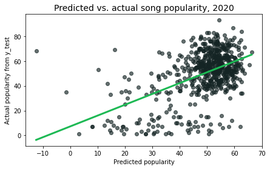

```python
# linear regression model for all characteristics for 2020 popularity

X_train, X_test, y_train, y_test = train_test_split(df_char_2020.drop(["name","popularity"], axis=1),df_char_2020['popularity'],train_size=.95)

model_2020 = lr().fit(X=X_train, y=y_train)

y_hat = model_2020.predict(X_test)
fig,ax = plt.subplots(figsize=(7,4))
plt.scatter(y_hat, y_test,alpha=0.65,color='#142424')
ax.set_xlabel('Predicted popularity')
ax.set_ylabel('Actual popularity from y_test')
ax.set_title("Predicted vs. actual song popularity, 2020",size=14)
m, b = np.polyfit(y_hat, y_test, 1)
print(''''Linear best fit line equation:
      y = %.3f*x + %.3f''' % (m,b))
plt.plot(np.unique(y_hat), np.poly1d(np.polyfit(y_hat, y_test, 1))(np.unique(y_hat)),color='#1DB954',lw=3)

plt.show()
```

The linear regression model based on song characteristics to predict 2020 popularity performs much better than the model of songs from all years

### b) Decision Tree Regressor

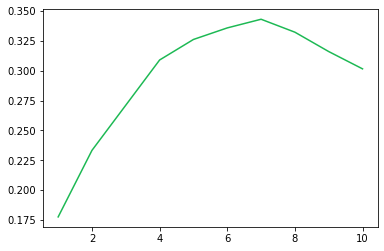

```
The max depth with the highest score is 7
```

```python
# tuning parameters

scores_dtr = pd.Series()
for i in range(1,11):
    scores_dtr.loc[i] = cross_val_score(dtr(max_depth=i),X = X_train,y = y_train).mean()
scores_dtr.plot(color="#1DB954")
plt.show()
print('The max depth with the highest score is %d' %scores_dtr.idxmax())
```

```
'Linear best fit line equation:
      y = 0.959*x + 3.324
```

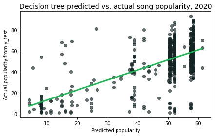

```python
X_train, X_test, y_train, y_test = train_test_split(df_char_2020.drop(["name","popularity"], axis=1),df_char_2020['popularity'],train_size=.95)
dtr_model = dtr(max_depth=7).fit(X_train, y_train)
yhat_dtr = dtr_model.predict(X_test)

fig,ax = plt.subplots(figsize=(7,4))
plt.scatter(yhat_dtr, y_test,alpha=0.65,color='#142424')
ax.set_xlabel('Predicted popularity')
ax.set_ylabel('Actual popularity from y_test')
ax.set_title("Decision tree predicted vs. actual song popularity, 2020",size=14)

m, b = np.polyfit(yhat_dtr, y_test, 1)
print(''''Linear best fit line equation:
      y = %.3f*x + %.3f''' % (m,b))
plt.plot(np.unique(yhat_dtr), np.poly1d(np.polyfit(yhat_dtr, y_test, 1))(np.unique(yhat_dtr)),color='#1DB954',lw=3)
plt.show()
```

#### 2020

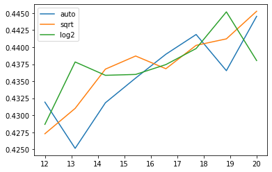

```python
# tuning parameters
score_list = []
feat_list = ['auto','sqrt', 'log2']
values = np.linspace(12,20,8)
X_train, X_test, y_train, y_test = train_test_split(df_char_2020.drop(["name","popularity"], axis=1),df_char_2020['popularity'],train_size=.95)

for el in feat_list:
    lis = []
    for n in values:
        sklearn_rf = rf(max_depth = n, max_features = el).fit(X_train,y_train)
        yhat_rf = sklearn_rf.score(X_test,y_test)
        lis.append(yhat_rf)
    score_list.append(lis)

plt.plot(values,score_list[0],label=feat_list[0])
plt.plot(values,score_list[1],label=feat_list[1])
plt.plot(values,score_list[2],label=feat_list[2])
plt.legend()
```

```
'Linear best fit line equation:
      y = 0.579*x + 21.354
```

[figure not shown]

```python
X_train, X_test, y_train, y_test = train_test_split(df_char_2020.drop(["name","popularity"], axis=1),df_char_2020['popularity'],train_size=.95)

rf_model = dtr(max_depth=19,max_features='log2').fit(X_train, y_train)
yhat_rf = rf_model.predict(X_test)

fig,ax = plt.subplots(figsize=(7,4))
plt.scatter(yhat_rf, y_test,alpha=0.65,color='#142424')
m, b = np.polyfit(yhat_rf, y_test, 1)
print(''''Linear best fit line equation:
      y = %.3f*x + %.3f''' % (m,b))
plt.plot(np.unique(yhat_rf), np.poly1d(np.polyfit(yhat_rf, y_test, 1))(np.unique(yhat_rf)),color='#1DB954',lw=3)

ax.set_xlabel('Predicted popularity')
ax.set_ylabel('Actual popularity from y_test')
ax.set_title("Random forest predicted vs. actual song popularity, 2020",size=14)
plt.show()
```

### Model Evaluation

We will use mean-squared error to evaluate the performance of the three models

```python
mse_dtr = mse(y_test,yhat_dtr)
rmse_dtr = mse_dtr**(0.5)
print('Decision tree root mean squared error is %.3f' %rmse_dtr)
```

```
Decision tree root mean squared error is 24.463
```

```python
mse_rf = mse(y_test,yhat_rf)
rmse_rf = mse_rf**(0.5)
print('Random forest root mean squared error is %.3f' %rmse_rf)
```

```
Random forest root mean squared error is 19.165
```

```python
mse_linreg = mse(y_test,y_hat)
rmse_linreg = mse_linreg**(0.5)
print('Linear regression root mean squared error is %.3f' %rmse_linreg)
```

```
Linear regression root mean squared error is 23.178
```